# Think Small

16-September, 2015

**Think** about solving your problems before trying to implement them

**Think** about solving your problems before trying to implement solutions

*especially* on distributed systems

Sometimes, evidently huge problems are **smaller** than they seem.

Sometimes, evidently huge problems are **smaller** than they seem.

Sometimes, "big data" systems suck.

information << data

—Michael Wu

## The cancer genome atlas

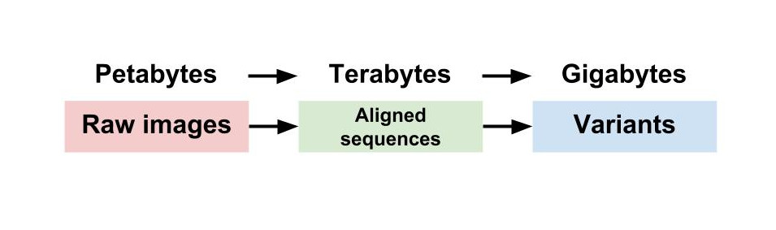

Big data…it's a nonsense term.

—Bill Cleveland, Interface 2015

## Examples

Our conclusion is not that the systems … are obviously bad, but rather that there is not yet much evidence that they are especially good.

—Frank McSherry on Spark, GraphX, Giraph, GraphLab

## Page rank

## Twitter_rv

| System | CPU Cores | Time (s) |
| --- | --- | --- |
| Spark/GraphX | 128 | 419 |
| Giraph | 128 | 596 |
| Graphlab | 128 | 249 |
| McSherry's Macbook Pro | 1 | 110 |

Follower network example, ~41M vertices 1.4B edges

This table shows 20 iterations of page rank computed by Frank McSherry on his laptop, compared to some big distribtued systems.

## Sparse SVD biclustering

Innovative algorithm by Lee, Shen, Huang, and Marron

and a faithful R package implementation (s4vd) by Martin Sill and Sebastian Kaiser

## Findings

- The method requires only a low-rank SVD in each iteration
- An inner matrix optimization problem could be (exactly) projected into a 1-d problem

These knock an \(m^3\) problem down to about an order \(m\) problem or so, where \(m\) is the number of data observations

## Example

1,000 \(\times\) 10,000 example matrix timed on a laptop

```r
library(s4vd)
set.seed(1)
x = matrix(rnorm(1000 * 10000), nrow=1000)
i = seq(from=1, to=nrow(x), by=2)
j = seq(from=1, to=ncol(x), by=2)
x[i,j] = rnorm(length(i)*length(j), mean=2, sd=0.5)
cl = biclust(x, method=BCssvd, K=1)
```

| Original routines | 3,522s |
| --- | --- |
| Reformulated routines | 20s |

## Network centrality

## A tiny part of the Bitcoin transaction graph

[interactive chart not shown]

## Viewed as an adjacency matrix \(A\):

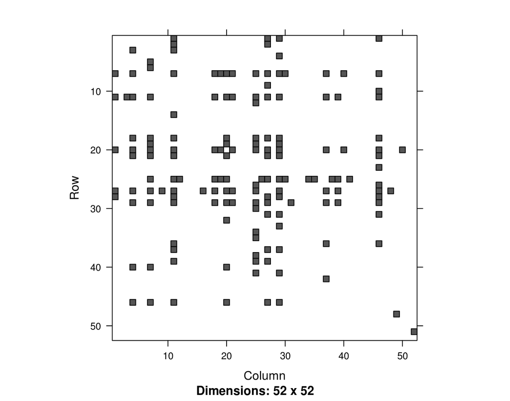

## Network centrality

It's easy to see that

\[ \left( A^k \right)_{i,j} \]

counts the number of paths of length \(k\) between vertices \(i\) and \(j\).

## Network centrality

\[ \left(A + A^2 + A^3 + \cdots \right)_{i,j} \]

counts the number of paths of *all* lengths between vertices \(i\) and \(j\).

## Network centrality

One interesting measure of centrality de-emphasizes longer paths

\[ I + 1 A + \frac{1}{2!}A^2 + \cdots = \exp(A). \]

Can be expensive to compute.

## Network centrality

Rodriguez et al. show that the top \(k\) most central network nodes are often found in low-dimensional subspaces related to the SVD.

And, they have a simple method that tells us when we've got a subspace *guaranteed* to contain the top \(k\) most central nodes.

## Bitcoin network centrality on a Chromebook

```r
load("bitcoin_from_to_graph.rdata")
t1 = proc.time()
x = topm(B,q=2,tol=0.1,m_b=5)
proc.time() - t1

# user system elapsed
# 86.970 24.350 111.605
```

Compute the top 5 most central nodes for the *entire* Bitcoin transaction graph.

## Compare to Padé approximant

On a 1000 \(\times\) 1000 subset

```r
t1 = proc.time()
ex = diag(expm(X) + expm(-X))/2
proc.time() - t1
# user system elapsed
# 151.080 0.220 151.552

order(ex,decreasing=TRUE)[1:5]
#[1] 11 25 27 29 74
```

```r
t1  = proc.time()
top = topm(X, type="cent")
proc.time() - t1
# user system elapsed
# 0.555 0.010 0.565

top$hubs
#[1] 11 25 27 29 74
```

## Google genomics and Spark (ADAM): not thinking small enough

## PCA on the 1000 genomes chrom. 20

A few lines of R code. A few minutes from start to finish on a laptop.

cf. https://youtu.be/ExNxi_X4qug

## PCA on the 1000 genomes chrom. 20

```r
library(Matrix)
p = pipe("zcat ALL.chr20.phase3_....genotypes.vcf.gz
         | sed /^#/d  | cut  -f '10-' | parser | cut -f '1-2'")
x = read.table(p, colClasses=c("integer","integer"), fill=TRUE)
chr20 = sparseMatrix(i=x[,2], j=x[,1], x=1.0)

print(dim(chr20))
# [1]    2504 1812841

library(irlba)
cm = colMeans(chr20)
p = irlba(chr20, nv=3, nu=3, dU=rep(1,nrow(chr20)), ds=1, dV=cm)

library(threejs)
scatterplot3js(p$u)
```

[interactive chart not shown]

AFR AMR EAS EUR SAS

[interactive chart not shown]

## What about more chromosomes?

Not too big a deal. Easy to supply a custom, column-wise chunked matrix-vector product.

## Overlap join

The overlap join finds overlapping regions between two tables of coordinates.

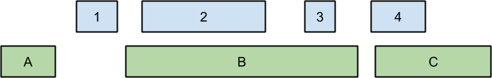

The overlap join finds overlapping regions between two tables of coordinates.

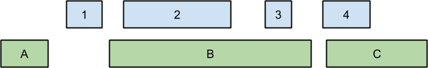

B overlaps with region 2 and 3.  
C overlaps with region 4.

## 1000 genomes on a cheap PC

Find overlaps between all 9,362,139 on chromosomes 7 and 8 against a table of 1,989 ranges.

| R data load from file | 260s |
| --- | --- |
| R IRanges find overlaps | 8s |
| R data.table find overlaps | 9s |
| Vertica data load from file | 303s |
| Vertica find overlaps | 28s |

## Linear mixed models

## FastLMM

Nifty recent work of Lippert, Listgarten, Liu, Kadie, Davidson, Heckerman at MSFT Research

*Beautifully simple* change of basis that reduces normally expensive large-scale mixed effects models to simpler (diagonal) form

Can be combined naturally with low-dimensional subspace projection

## Practical thoughts

Projection methods turn “ big data ” into data

Projection methods turn “ big data ” into data

Changing bases can exploit underlying structure to simplify problems

## IRLBA

- State of the art partial SVD by Baglama and Reichel
- Competetive with Martinsson, Rokhlin, et al. methods.
- On CRAN, development on GitHub recent improvements for PCA, partial symmetric eigensystems, …

## References

- https://community.lithium.com/t5/Science-of-Social-blog/The-Big-Data-Fallacy-Data-Information/ba-p/59250
- http://www.frankmcsherry.org/graph/scalability/cost/2015/01/15/COST.html
- https://github.com/bwlewis/s4vd (sparse svd biclustering)
- http://compbio.cs.uic.edu/data/bitcoin/ (bitcoin data)
- https://github.com/googlegenomics/spark-examples
- http://htmlwidgets.org (the interactive R plots)
- https://github.com/bwlewis/IRL (irlba method, also on CRAN)
- https://github.com/bwlewis/1000_genomes_examples
- http://bwlewis.github.io/1000_genomes_examples/ranges.html
- http://www.nature.com/nmeth/journal/v8/n10/abs/nmeth.1681.html (Fast LMM)
- http://illposed.net